# Milestone Report

Dom Foord

16/07/2021

## Overview

This is the Milestone Report for the Coursera Data Science Capstone project, sponsered by SwiftKey. In this project, we will apply our knowledge of data science to a problem related to natural language processing (NLP). The project is sponsored by SwiftKey.

The objective of the project is to create a text-prediction application using the R Shiny package that predicts words using a natural language processing model - given a word or phrase as input, the application will try to predict the next word. The predictive model will be trained using a corpus, a collection of written texts, called the HC Corpora which has been filtered by language.

We begin by giving a report of the exploratory data analysis required, consisting of the following tasks:

- We obtain the data and load it into the RStudio environment
- We clean the Data (if required)
- We create a brief statistical analysis of the data at hand
- We report any interesting findings
- We indicate what we are going to do to create the required algorithms for the NLP

## Loading Library

```r
# Load necessary R libraries
library(dplyr)
library(doParallel)
library(stringi)
library(SnowballC)
library(tm)
```

```r
# To solve rJava package issues while loading it or Rweka, set the directory of your Java location by setting it before loading the library:
if(Sys.getenv("JAVA_HOME")!="")
      Sys.setenv(JAVA_HOME="")
#options(java.home="C:\\Program Files\\Java\\jre1.8.0_171\\")
#library(rJava)
library(RWeka)
library(ggplot2)
```

## Downloading and Importing Data

The data is from HC Corpora with choice of 4 languages, but only English will be used. The dataset consists of the three files **en_US.blogs.txt**, **en_US.news.txt**, and **en_US.twitter.txt**.

```r
if(!file.exists("Coursera-SwiftKey.zip")) {
      download.file("https://d396qusza40orc.cloudfront.net/dsscapstone/dataset/Coursera-SwiftKey.zip", "Coursera-SwiftKey.zip")
      unzip("Coursera-SwiftKey.zip")
}
# Read the blogs and twitter files using readLines
blogs <- readLines("final/en_US/en_US.blogs.txt", warn = FALSE, encoding = "UTF-8")
twitter <- readLines("final/en_US/en_US.twitter.txt", warn = FALSE, encoding = "UTF-8")
# Read the news file using binary/binomial mode as there are special characters in the text
con <- file("final/en_US/en_US.news.txt", open="rb")
news <- readLines(con, encoding = "UTF-8")
close(con)
rm(con)
```

## Original Data/Population Summary Stats

We calculate some summary stats for each file: Size in Megabytes, number of entries (rows), total characters and length of longest entry.

```r
# Get file sizes
blogs_size <- file.info("final/en_US/en_US.blogs.txt")$size / 1024 ^ 2
news_size <- file.info("final/en_US/en_US.news.txt")$size / 1024 ^ 2
twitter_size <- file.info("final/en_US/en_US.twitter.txt")$size / 1024 ^ 2
pop_summary <- data.frame('File' = c("Blogs","News","Twitter"),
                      "File_Size_in_MB" = c(blogs_size, news_size, twitter_size),
                      'Number_of_Lines' = sapply(list(blogs, news, twitter), function(x){length(x)}),
                      'Total_Characters' = sapply(list(blogs, news, twitter), function(x){sum(nchar(x))}),
                      Total_Words = sapply(list(blogs,news,twitter),stri_stats_latex)[4,],
                      'MaxCharacters' = sapply(list(blogs, news, twitter), function(x){max(unlist(lapply(x, function(y) nchar(y))))})
                      )
pop_summary
```

```
##      File File_Size_in_MB Number_of_Lines Total_Characters Total_Words
## 1   Blogs        200.4242          899288        206824505    37570839
## 2    News        196.2775         1010242        203223159    34494539
## 3 Twitter        159.3641         2360148        162096031    30451128
##   MaxCharacters
## 1         40833
## 2         11384
## 3           140
```

The above population summary shows that Blogs and News are files of both around 200 MB, with Twitter at a little less. The word count comes in at around 30 million per file, with the most taken up by Blogs. In terms of line counts however, Twitter comes top.

## Sampling

Owing to the size of the data, we are instead going to work with a subset at 5% of the total. We hope that this gives us enough of a representative sample to make a model that can apply to the entire data set. We then clean the data and create the corpus. We binomially sample to get a random 5% of the data.

```r
set.seed(10)
# Remove all non-english characters
blogs <- iconv(blogs, "latin1", "ASCII", sub="")
news <- iconv(news, "latin1", "ASCII", sub="")
twitter <- iconv(twitter, "latin1", "ASCII", sub="")
# Binomial sampling of the data
sample <- function(population, percentage) {
      return(population[as.logical(rbinom(length(population),1,percentage))])
}
# Set sample percentage
percent <- 0.05

samp_blogs   <- sample(blogs, percent)
samp_news   <- sample(news, percent)
samp_twitter   <- sample(twitter, percent)
dir.create("sample", showWarnings = FALSE)

samp_data <- c(samp_blogs,samp_news,samp_twitter)
write(samp_data, "sample/sampleData.txt")
```

### Sample Summary Stats

We calculate some summary stats for each file on sample data.

```r
samp_summary <- data.frame(
      File = c("blogs","news","twitter"),
      t(rbind(sapply(list(samp_blogs,samp_news,samp_twitter),stri_stats_general),
              TotalWords = sapply(list(samp_blogs,samp_news,samp_twitter),stri_stats_latex)[4,]))
)
samp_summary
```

```
##      File  Lines LinesNEmpty    Chars CharsNWhite TotalWords
## 1   blogs  44820       44813 10305669     8481988    1862344
## 2    news  50480       50480 10178559     8504440    1726424
## 3 twitter 117802      117802  8081879     6683738    1517599
```

```r
# remove temporary variables
rm(blogs, news, twitter, samp_blogs, samp_news, samp_twitter, samp_data, pop_summary, samp_summary)
```

## Data Preprocessing

The final selected text data needs to be cleaned to be used in the word prediction model. We can create a cleaned/tidy corpus file **sampleData** of the text.

### Cleaning the Data

We clean the data by removing whitespace, numbers, URLs, punctuation, profanity etc.

```r
directory <- file.path(".", "sample")

sample_data <- VCorpus(DirSource(directory)) # load the data as a corpus
sample_data <- tm_map(sample_data, content_transformer(tolower))
# Removing Profanity Words using one of the available dictionaries of 1384 words
profanity_words = readLines("http://www.cs.cmu.edu/~biglou/resources/bad-words.txt")
profanity_words = profanity_words[-(which(profanity_words%in%c("refugee","reject","remains","screw","welfare","sweetness","shoot","sick","shooting","servant","sex","radical","racial","racist","republican","public","molestation","mexican","looser","lesbian","liberal","kill","killing","killer","heroin","fraud","fire","fight","fairy","^die","death","desire","deposit","crash","^crim","crack","^color","cigarette","church","^christ","canadian","cancer","^catholic","cemetery","buried","burn","breast","^bomb","^beast","attack","australian","balls","baptist","^addict","abuse","abortion","amateur","asian","aroused","angry","arab","bible")==TRUE))]
sample_data <- tm_map(sample_data,removeWords, profanity_words)
## removing URLs
removeURL <- function(x) gsub("http[[:alnum:]]*", "", x)
sample_data <- tm_map(sample_data, content_transformer(removeURL))

## Replacing special chars with space
toSpace <- content_transformer(function(x, pattern) gsub(pattern, " ", x))
sample_data <- tm_map(sample_data, toSpace, "(f|ht)tp(s?)://(.*)[.][a-z]+")
sample_data <- tm_map(sample_data, toSpace, "@[^\\s]+")
sample_data <- tm_map(sample_data, tolower) # convert to lowercase
sample_data <- tm_map(sample_data, removePunctuation) # remove punctuation
sample_data <- tm_map(sample_data, removeNumbers) # remove numbers
sample_data <- tm_map(sample_data, stripWhitespace) # remove extra whitespace
sample_data <- tm_map(sample_data, PlainTextDocument)
sample_corpus <- data.frame(text=unlist(sapply(sample_data,'[',"content")),stringsAsFactors = FALSE)
head(sample_corpus)
```

```
##                                                                                                                                                                                                                                                                                                          …
## character(0).content1                                                                                                                                                                                                                                                                                    …
## character(0).content2 even if you dont like the so called screwball comedy that some critic also called sex comedy without sex whose trouble in paradise gives a perfect example you could enjoy two things from this movie the typical art deco interior design in mme colet house and the beautiful gow…
## character(0).content3                                                                                                                                                                                                                                                     cat is looking for more picture…
## character(0).content4                                                                                                              sunday the festivities continued i went back to shadowbox to see back to the garden again told ya i love that place then after that was over i had to work at the stor…
## character(0).content5                                                                    they are both chunky knits and were a complete bargainthe green was and the multi colour knit was the charity shops have now started putting out their winter stocks so using these knits as inspiration why don…
## character(0).content6                                                                                                                                                                           its official i made the spellbinders team its been an amazing year and i am so glad that it doesnt have t…
```

After the above transformations the first review looks like:

```r
inspect(sample_data[1])
```

```
## <<VCorpus>>
## Metadata:  corpus specific: 0, document level (indexed): 0
## Content:  documents: 1
##
## [[1]]
## <<PlainTextDocument>>
## Metadata:  7
## Content:  chars: 18682810
```

## N-gram Tokenization

Now the corpus **sample_data** has cleaned data. We need to format this cleaned data in to a format which is most useful for NLP. The format is N-grams stored in Term Document Matrices or Document Term Matrix. We use a Document Term Matrix (DTM) representation: documents as the rows, terms/words as the columns, frequency of the term in the document as the entries. Because the number of unique words in the corpus the dimension can be large. N-gram models are created to explore word frequencies. We can use the RWeka package to create N-grams of any length - we limit ourselves to tuples of length less than or equal to 4.

```r
review_dtm <- DocumentTermMatrix(sample_data)
review_dtm
```

```
## <<DocumentTermMatrix (documents: 1, terms: 104463)>>
## Non-/sparse entries: 104463/0
## Sparsity           : 0%
## Maximal term length: 110
## Weighting          : term frequency (tf)
```

### Unigram Analysis

Unigram Analysis shows that which words are the most frequent and what their frequency is.

```r
unigramTokenizer <- function(x) {
      NGramTokenizer(x, Weka_control(min = 1, max = 1))
}

unigrams <- DocumentTermMatrix(sample_data, control = list(tokenize = unigramTokenizer))
```

### Bigram analysis

Bigram analysis shows that which pairs of words are the most frequent together.

```r
BigramTokenizer <- function(x) {
      NGramTokenizer(x, Weka_control(min = 2, max = 2))
}
bigrams <- DocumentTermMatrix(sample_data, control = list(tokenize = BigramTokenizer))
```

### Trigram Analysis

Similarly, we can analyse trigrams by seeing what three word samples we can work with.

```r
trigramTokenizer <- function(x) {
      NGramTokenizer(x, Weka_control(min = 3, max = 3))
}
trigrams <- DocumentTermMatrix(sample_data, control = list(tokenize = trigramTokenizer))
```

### 4-gram Analysis

Similarly we work on 4-tuples of words, known as a 4-gram.

```r
fourgramTokenizer <- function(x) {
      NGramTokenizer(x, Weka_control(min = 4, max = 4))
}
fourgrams <- DocumentTermMatrix(sample_data, control = list(tokenize = fourgramTokenizer))
```

## Exploratory Data Analysis

Now we can perform exploratory analysis on the tidy data. For each Term Document Matrix, we list the most common unigrams, bigrams, trigrams and 4-grams.

#### Top 10 frequencies of unigrams

```r
unigrams_frequency <- sort(colSums(as.matrix(unigrams)),decreasing = TRUE)
unigrams_freq_df <- data.frame(word = names(unigrams_frequency), frequency = unigrams_frequency)
head(unigrams_freq_df, 10)
```

```
##      word frequency
## the   the    183506
## and   and     95477
## that that     39230
## for   for     34120
## with with     26331
## was   was     24765
## you   you     19432
## this this     18600
## have have     17514
## but   but     17120
```

#### Plot the Unigram frequency

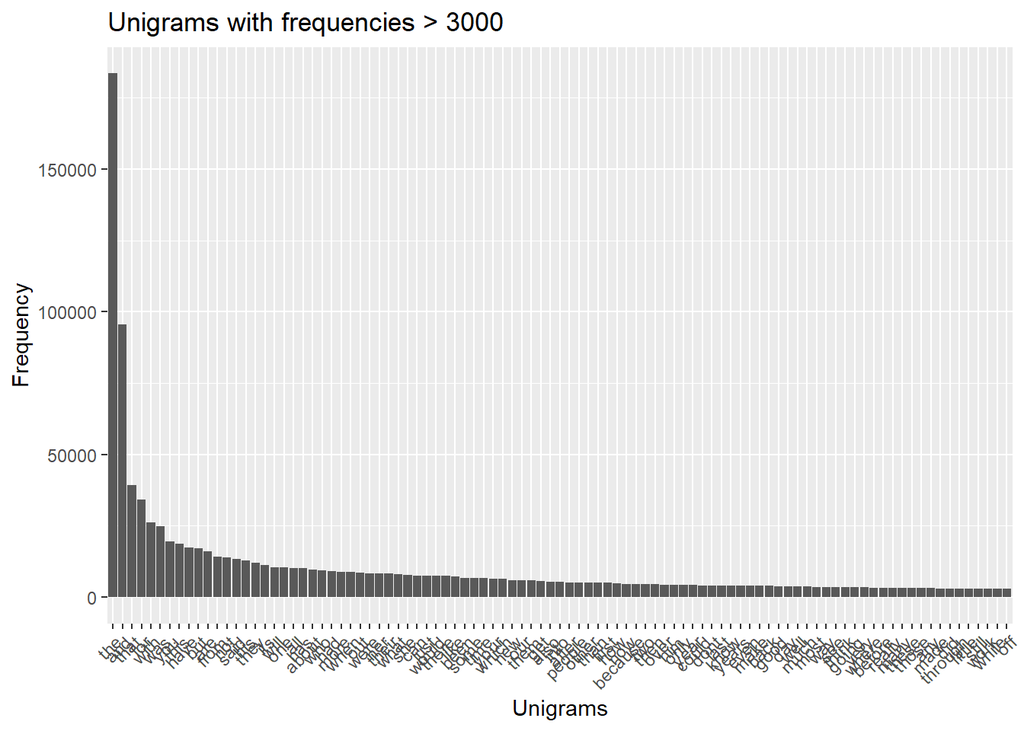

```r
unigrams_freq_df %>%
      filter(frequency > 3000) %>%
      ggplot(aes(reorder(word,-frequency), frequency)) +
      geom_bar(stat = "identity") +
      ggtitle("Unigrams with frequencies > 3000") +
      xlab("Unigrams") + ylab("Frequency") +
      theme(axis.text.x = element_text(angle = 45, hjust = 1))
```

#### Top 10 frequencies of bigrams

```r
bigrams_frequency <- sort(colSums(as.matrix(bigrams)),decreasing = TRUE)
bigrams_freq_df <- data.frame(word = names(bigrams_frequency), frequency = bigrams_frequency)
head(bigrams_freq_df, 10)
```

```
##              word frequency
## of the     of the     18089
## in the     in the     15841
## to the     to the      8080
## on the     on the      7148
## for the   for the      6068
## to be       to be      5567
## and the   and the      5467
## at the     at the      5038
## in a         in a      4636
## with the with the      4303
```

Here, we create a generic function to plot the top 50 frequencies for bigrams and trigrams.

```r
hist_plot <- function(data, label) {
      ggplot(data[1:50,], aes(reorder(word, -frequency), frequency)) +
            labs(x = label, y = "Frequency") +
            theme(axis.text.x = element_text(angle = 60, size = 12, hjust = 1)) +
            geom_bar(stat = "identity", fill = I("grey50"))
}
```

#### Plot the bigram frequency

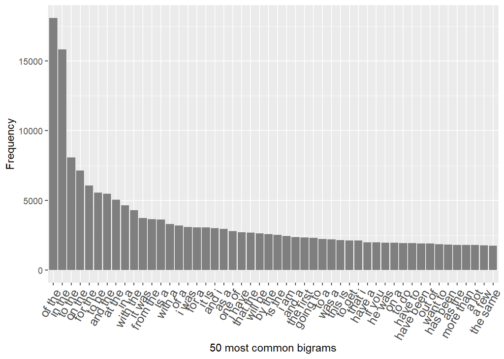

```r
hist_plot(bigrams_freq_df, "50 most common bigrams")
```

#### Top 10 frequencies of trigrams

```r
trigrams_frequency <- sort(colSums(as.matrix(trigrams)),decreasing = TRUE)
trigrams_freq_df <- data.frame(word = names(trigrams_frequency), frequency = trigrams_frequency)
head(trigrams_freq_df, 10)
```

```
##                    word frequency
## one of the   one of the      1420
## a lot of       a lot of      1175
## as well as   as well as       678
## to be a         to be a       596
## out of the   out of the       580
## some of the some of the       576
## the end of   the end of       572
## it was a       it was a       546
## part of the part of the       545
## be able to   be able to       500
```

#### Plot the Trigram frequency

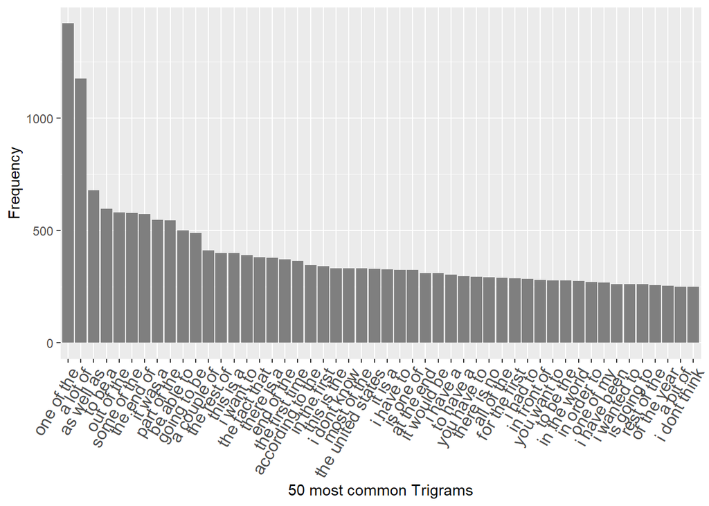

```r
hist_plot(trigrams_freq_df, "50 most common Trigrams")
```

#### Top 10 frequencies of 4-grams

```r
fourgrams_frequency <- sort(colSums(as.matrix(fourgrams)),decreasing = TRUE)
fourgrams_freq_df <- data.frame(word = names(fourgrams_frequency), frequency = fourgrams_frequency)
head(fourgrams_freq_df, 10)
```

```
##                                  word frequency
## the end of the         the end of the       311
## at the end of           at the end of       257
## the rest of the       the rest of the       252
## for the first time for the first time       214
## at the same time     at the same time       191
## one of the most       one of the most       172
## is one of the           is one of the       170
## when it comes to     when it comes to       163
## to be able to           to be able to       146
## in the middle of     in the middle of       141
```

#### Plot the 4-gram frequency

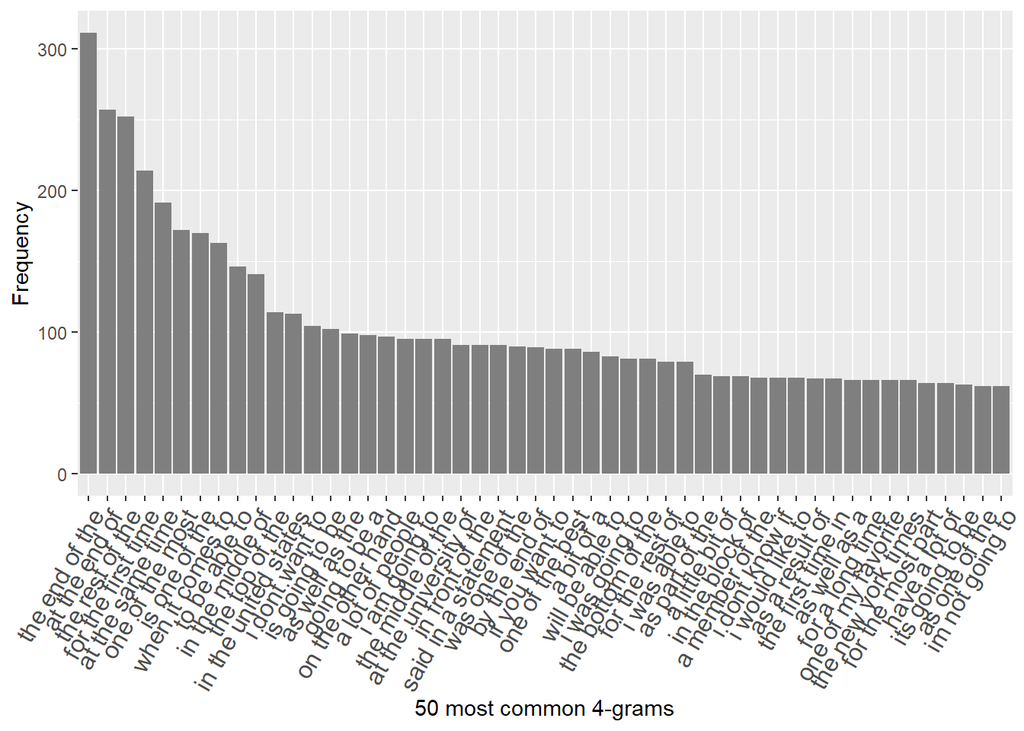

```r
hist_plot(fourgrams_freq_df, "50 most common 4-grams")
```

## Further Actions

This concludes the exploratory analysis. As a further step a model will be created and integrated into a Shiny app for word prediction.

The corpus has been converted to N-grams stored in Document Term Matrix (DTM) and then converted to data frames of frequencies. This format should be useful for predicting the next word in a sequence of words. For example, when looking at a string of 3 words the most likely next word can be guessed by investigating all 4-grams starting with these three words and choosing the most frequent one.

For the Shiny application, the plan is to create an application with a simple interface where the user can enter a string of text. Our prediction model will then give a list of suggested words to update the next word.